# Logistic Regression: Feature Selection and Cross Validation

Will Doyle

Today we’re going to continue or modeling approach by using a model designed to select those features which are most closely associated with a student yielding, and dropping correlated variables that don’t contribute as much to the model. We’ll validate our approach using cross validation, just like we did in the context of regression.

```r
library(modelr)
library(tidyverse)
library(tidymodels)
library(knitr)
```

```r
ad<-read_rds("admit_data.rds")
```

## Data Wrangling

When setting up our dependent variable, we need to specify the reference category. This is very important and affects how we interpret the results of the model once we have them. I’m also going to make some adjustments, measure SAT in 100s and income and distance in 1000s. This will make it easier to understand our estimates.

```r
ad_sub <- ad %>%
  mutate(yield_f = as_factor(ifelse(yield == 1, "Yes", "No"))) %>%
  mutate(yield_f = relevel(yield_f, ref = "No")) %>% ## This is what I forgot last time
  mutate(sat=sat/100,
         income=income/1000,
         distance=distance/1000)%>%
  select(ID,
         yield_f,
         legacy,
         visit,
         registered,
         sent_scores,
         sat,
         income,
         gpa,
         distance,
         net_price)
```

## Settting the Model

We’re going to run a LASSO model again, this time using the logit link function. To do this, we need to use the `logistic_reg` specification for a `glmnet` model. Note that this is just like what we did in regression, except we’re specifying a logistic regression for classification as opposed to a linear model.

Remember that the lasso downweights variables mostly by dropping variables that are highly correlated with one another, leaving only one of the correlated variables as contributors to the model. We set the degree to which this penalty will be implemented by setting the “penalty” variable in the model specification.

```r
penalty_spec<-.1

mixture_spec<-1

lasso_logit_mod<-
  logistic_reg(penalty=penalty_spec,
             mixture=mixture_spec) %>%
  set_engine("glmnet")%>%
  set_mode("classification")
```

## Formula and Recipe

We’ll set up a formula that includes all of the variables in the dataset. Notice that because we’re using the lasso model, I will go ahead and normalize all of the predictors, turning them into Z scores.

```r
admit_formula <- as.formula(
                        "yield_f~.")

admit_recipe<-recipe(admit_formula,ad_sub)%>%
  update_role(ID, new_role = "id variable")%>%
  step_log(distance)%>%
  step_normalize(all_predictors())%>%
  step_naomit(all_predictors())
```

## Workflow

Having set up the model and the recipe, I can create a workflow.

```r
ad_wf<-workflow()%>%
  add_model(lasso_logit_mod)%>%
  add_recipe(admit_recipe)
```

## Set Resamples

To properly evaluate model fit, we need to resample as always. We’ll use a Monte Carlo resample. I’m using 25 resamples for this example, but in practice we’d want to do more, 1000 resamples would be typical in many applications.

```r
ad_rs<-mc_cv(ad_sub,times=25) # DO MORE IN PRACTICE
```

## Fit the Model: THIS WILL TAKE A FEW SECONDS, JUST BREATHE . . .

```r
ad_lasso_fit<-ad_wf%>%
  fit_resamples(ad_rs,  metrics = metric_set(roc_auc, sens, spec,accuracy))
```

The code above fits the model to the resampled dataset, generating parameter estimates from the training split and estimates of predictive accuracy from the testing split.

## Check Accuracy of the Model

We can use the `collect_metrics` command to get the average accuracy and AUC from our model.

```r
ad_lasso_fit%>%
  collect_metrics()
```

```
## # A tibble: 4 × 6
##   .metric  .estimator  mean     n std_err .config
##   <chr>    <chr>      <dbl> <int>   <dbl> <chr>
## 1 accuracy binary     0.728    25 0.00485 Preprocessor1_Model1
## 2 roc_auc  binary     0.902    25 0.00258 Preprocessor1_Model1
## 3 sens     binary     0.166    25 0.00959 Preprocessor1_Model1
## 4 spec     binary     0.984    25 0.00175 Preprocessor1_Model1
```

We can also plot the auc for every resampled version:

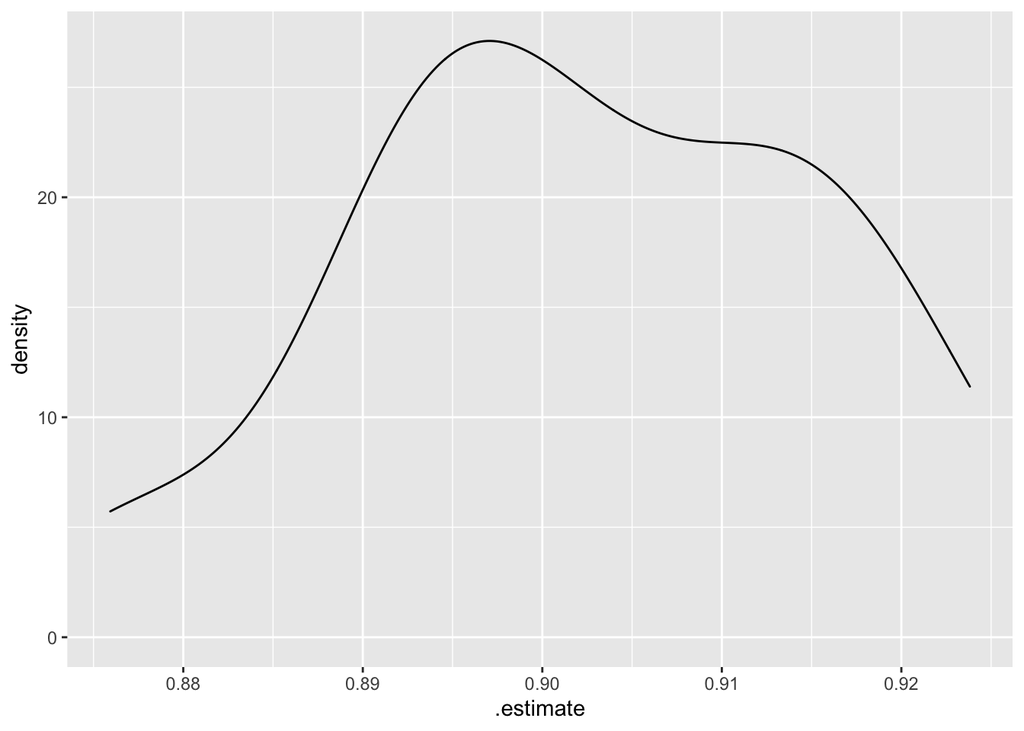

```r
ad_lasso_fit%>%
  unnest(.metrics)%>%
  filter(.metric=="roc_auc")%>%
  ggplot(aes(x=.estimate))+
  geom_density()
```

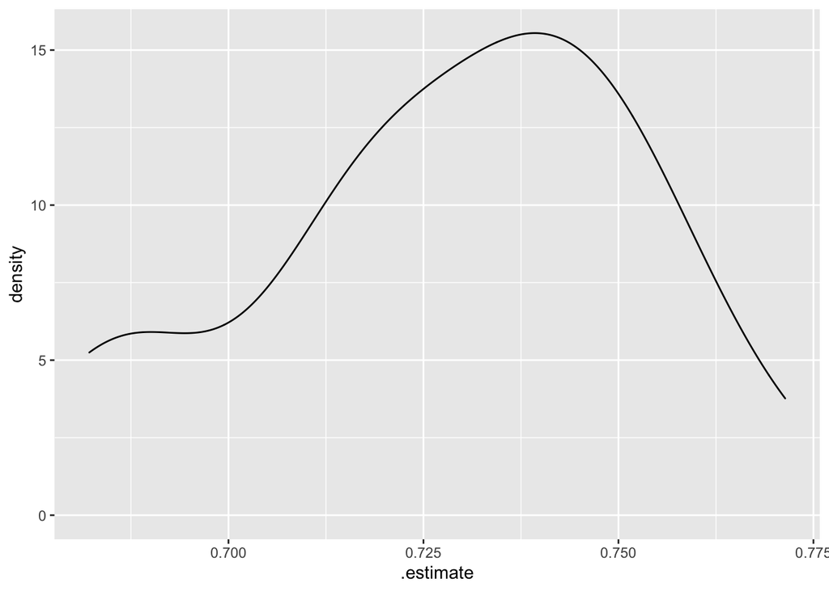

```r
ad_lasso_fit%>%
  unnest(.metrics)%>%
  filter(.metric=="accuracy")%>%
  ggplot(aes(x=.estimate))+
  geom_density()
```

*Quick Exercise: Plot the Accuracy of the model across resamples*

## Finalize Workflow

We can now select the best model fit from our resamples, and apply it to the full dataset.

```r
ad_lasso_final <- finalize_workflow(ad_wf,                                      select_best(ad_lasso_fit,metric="roc_auc")) %>%
  fit(ad_sub)
```

## Parameter Estimates

We can then examine the parameter estimates from the model run on the full dataset.

```r
ad_lasso_final%>%
  extract_fit_parsnip()%>%
  tidy()%>%
  kable()
```

| term | estimate | penalty |
| --- | --- | --- |
| (Intercept) | 0.8791537 | 0.1 |
| legacy | 0.0000000 | 0.1 |
| visit | 0.0000000 | 0.1 |
| registered | 0.0000000 | 0.1 |
| sent_scores | 0.0000000 | 0.1 |
| sat | 0.2278358 | 0.1 |
| income | 0.7147746 | 0.1 |
| gpa | 0.0000000 | 0.1 |
| distance | 0.0000000 | 0.1 |
| net_price | 0.0000000 | 0.1 |

With the very high penalty, the model is selecting just sat and income as the best predictors of yield.

## Hyperparameter Tuning

There’s no guarantee we chose the right penalty. Let’s see what difference it makes by using hyperparameter tuning to allow the penalty to vary across a sensible range of possibilities.

## Set Up Lasso Model

To set up the model for tuning, we’re now setting `penalty=tune()`.

```r
lasso_logit_mod<-
  logistic_reg(penalty=tune(),
             mixture=mixture_spec) %>%
  set_engine("glmnet")%>%
  set_mode("classification")
```

## Set Grid

Using the `grid_regular` command will give us a reasonable set of possible penalties to work with.

```r
lasso_grid<-grid_regular(parameters(lasso_logit_mod) ,levels=10)
```

## Update Model

With this new specification, we can update the workflow.

```r
ad_wf<-ad_wf%>%
  update_model(lasso_logit_mod)
```

## Fit Using the Grid: THIS WILL TAKE A WHILE; ENHANCE YOUR CALM . . .

Now we can fit the model to the data, fitting each of the possible 10 penalty to values to each of the resampled datasets.

```r
ad_tune_fit <-
  ad_wf %>%
    tune_grid(ad_rs,grid=lasso_grid, metrics = metric_set(roc_auc, sens, spec,accuracy))
```

## Show AUC and other measures of fit in resamples

Having fit the model, we can take a look at how many different measures of model fit differ when using different penalties.

```r
ad_tune_fit%>%
  collect_metrics()%>%
  filter(.metric=="roc_auc")%>%
  arrange(-mean)
```

```
## # A tibble: 10 × 7
##          penalty .metric .estimator  mean     n std_err .config
##            <dbl> <chr>   <chr>      <dbl> <int>   <dbl> <chr>
##  1 0.000464      roc_auc binary     0.919    25 0.00257 Preprocessor1_Model07
##  2 0.0000000001  roc_auc binary     0.919    25 0.00257 Preprocessor1_Model01
##  3 0.00000000129 roc_auc binary     0.919    25 0.00257 Preprocessor1_Model02
##  4 0.0000000167  roc_auc binary     0.919    25 0.00257 Preprocessor1_Model03
##  5 0.000000215   roc_auc binary     0.919    25 0.00257 Preprocessor1_Model04
##  6 0.00000278    roc_auc binary     0.919    25 0.00257 Preprocessor1_Model05
##  7 0.0000359     roc_auc binary     0.919    25 0.00257 Preprocessor1_Model06
##  8 0.00599       roc_auc binary     0.919    25 0.00253 Preprocessor1_Model08
##  9 0.0774        roc_auc binary     0.903    25 0.00257 Preprocessor1_Model09
## 10 1             roc_auc binary     0.5      25 0       Preprocessor1_Model10
```

This tells us that smaller penalties are generally yielding better AUC.

*Quick Exercise: Output the results for the other measures of model fit (accuracy, sensitivity, specificity). What do these tell you?*

```r
ad_tune_fit%>%
  collect_metrics()%>%
  filter(.metric=="accuracy")%>%
  arrange(-mean)
```

```
## # A tibble: 10 × 7
##          penalty .metric  .estimator  mean     n std_err .config
##            <dbl> <chr>    <chr>      <dbl> <int>   <dbl> <chr>
##  1 0.0000000001  accuracy binary     0.854    25 0.00343 Preprocessor1_Model01
##  2 0.00000000129 accuracy binary     0.854    25 0.00343 Preprocessor1_Model02
##  3 0.0000000167  accuracy binary     0.854    25 0.00343 Preprocessor1_Model03
##  4 0.000000215   accuracy binary     0.854    25 0.00343 Preprocessor1_Model04
##  5 0.00000278    accuracy binary     0.854    25 0.00343 Preprocessor1_Model05
##  6 0.0000359     accuracy binary     0.854    25 0.00343 Preprocessor1_Model06
##  7 0.000464      accuracy binary     0.854    25 0.00354 Preprocessor1_Model07
##  8 0.00599       accuracy binary     0.851    25 0.00352 Preprocessor1_Model08
##  9 0.0774        accuracy binary     0.775    25 0.00419 Preprocessor1_Model09
## 10 1             accuracy binary     0.689    25 0.00342 Preprocessor1_Model10
```

```r
ad_tune_fit%>%
  collect_metrics()%>%
  filter(.metric=="sens")%>%
  arrange(-mean)
```

```
## # A tibble: 10 × 7
##          penalty .metric .estimator  mean     n std_err .config
##            <dbl> <chr>   <chr>      <dbl> <int>   <dbl> <chr>
##  1 0.0000000001  sens    binary     0.781    25 0.00720 Preprocessor1_Model01
##  2 0.00000000129 sens    binary     0.781    25 0.00720 Preprocessor1_Model02
##  3 0.0000000167  sens    binary     0.781    25 0.00720 Preprocessor1_Model03
##  4 0.000000215   sens    binary     0.781    25 0.00720 Preprocessor1_Model04
##  5 0.00000278    sens    binary     0.781    25 0.00720 Preprocessor1_Model05
##  6 0.0000359     sens    binary     0.781    25 0.00720 Preprocessor1_Model06
##  7 0.000464      sens    binary     0.780    25 0.00734 Preprocessor1_Model07
##  8 0.00599       sens    binary     0.763    25 0.00787 Preprocessor1_Model08
##  9 0.0774        sens    binary     0.369    25 0.00987 Preprocessor1_Model09
## 10 1             sens    binary     0        25 0       Preprocessor1_Model10
```

```r
ad_tune_fit%>%
  collect_metrics()%>%
  filter(.metric=="spec")%>%
  arrange(-mean)
```

```
## # A tibble: 10 × 7
##          penalty .metric .estimator  mean     n std_err .config
##            <dbl> <chr>   <chr>      <dbl> <int>   <dbl> <chr>
##  1 1             spec    binary     1        25 0       Preprocessor1_Model10
##  2 0.0774        spec    binary     0.959    25 0.00235 Preprocessor1_Model09
##  3 0.00599       spec    binary     0.890    25 0.00296 Preprocessor1_Model08
##  4 0.000464      spec    binary     0.887    25 0.00328 Preprocessor1_Model07
##  5 0.0000000001  spec    binary     0.887    25 0.00326 Preprocessor1_Model01
##  6 0.00000000129 spec    binary     0.887    25 0.00326 Preprocessor1_Model02
##  7 0.0000000167  spec    binary     0.887    25 0.00326 Preprocessor1_Model03
##  8 0.000000215   spec    binary     0.887    25 0.00326 Preprocessor1_Model04
##  9 0.00000278    spec    binary     0.887    25 0.00326 Preprocessor1_Model05
## 10 0.0000359     spec    binary     0.887    25 0.00326 Preprocessor1_Model06
```

We can plot the results and confirm that suspicion:

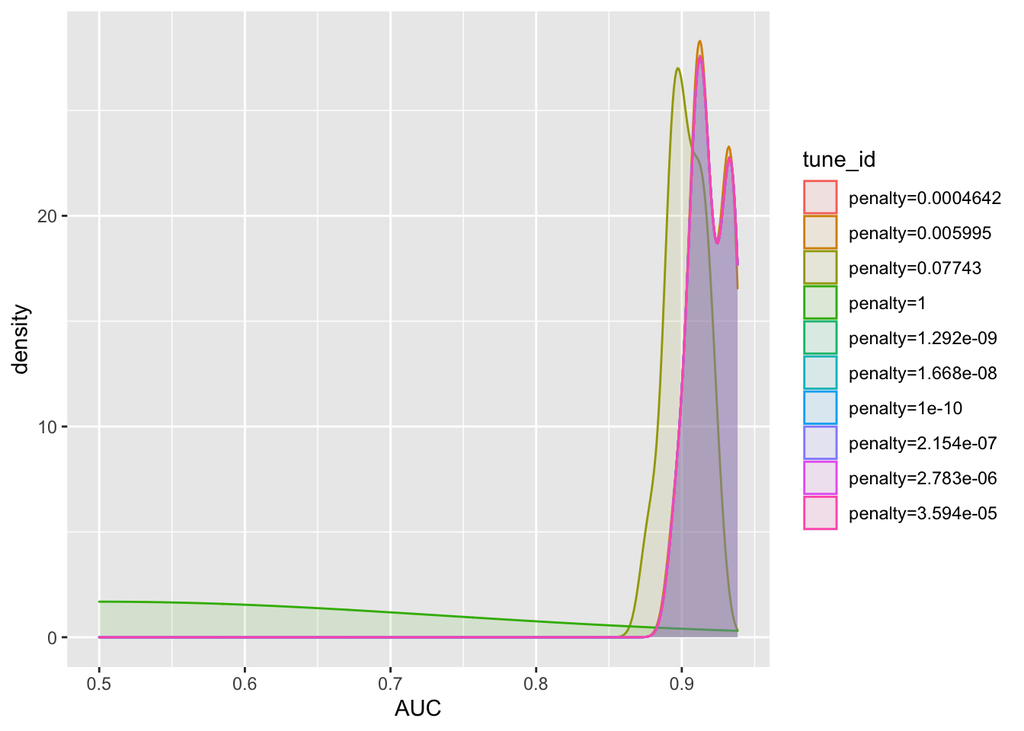

```r
ad_tune_fit%>%
unnest(.metrics)%>%
  filter(.metric=="roc_auc")%>%
  mutate(tune_id=paste0("penalty=",prettyNum(penalty,digits=4))) %>%
  select(tune_id,.estimate)%>%
  rename(AUC=.estimate)%>%
  ggplot(aes(x=AUC,color=tune_id,fill=tune_id))+
  geom_density(alpha=.1)
```

## Choose best model and fit to training data

Having fit the model to resamples and identified the best model fit through cross validation, we can select that model and apply it to the full dataset.

```r
ad_final <-
  finalize_workflow(ad_wf,
                    select_best(ad_tune_fit,
                                metric = "roc_auc")) %>%
  fit(ad_sub)
```

The object `ad_final` is a final fitted workflow, which we can use to examine parameter estimates and generate predicted probabilities.

## Examine Parameter Estimates

With that model fit in hand, we can check on our parameter estimates.

```r
ad_final%>%
  extract_fit_parsnip()%>%
  tidy()%>%
  mutate(penalty=prettyNum(penalty,digits=4))%>%
  kable()
```

| term | estimate | penalty |
| --- | --- | --- |
| (Intercept) | 2.8709837 | 0.0004642 |
| legacy | 0.2279305 | 0.0004642 |
| visit | 0.1392716 | 0.0004642 |
| registered | 0.2243953 | 0.0004642 |
| sent_scores | 0.2953763 | 0.0004642 |
| sat | 0.0000000 | 0.0004642 |
| income | 5.0013621 | 0.0004642 |
| gpa | 0.4059959 | 0.0004642 |
| distance | -0.3990855 | 0.0004642 |
| net_price | -0.8248575 | 0.0004642 |

Notice how SAT has been downweighted to 0, while income is a strong predictor.

## Next Steps

To improve model fit from here, we could examine the data a bit more carefully and see if there are other ways we might structure it, including other transformations of the variables.

## Extension: Predicting from the fitted model

To make out-of-sample predictions from the final fit, we need to specify specific values of the variables of interest. Here I’m going to allow net price to vary from its minimum to its maximum to in 100 steps.

```r
hypo_data <- ad %>%
  data_grid(ID="1",
            legacy=0,
            visit=1,
            registered=1,
            sent_scores=1,
            sat=14,
            income=95,
            gpa=3.9,
            distance=.1,
            net_price=seq_range(net_price,n=100)
            )
```

Then I can predict from the final fitted workflow `ad_final`

```r
pred_prob<-ad_final%>%
  predict(hypo_data,type="prob")%>%
  bind_cols(hypo_data)
```

… and plot the result

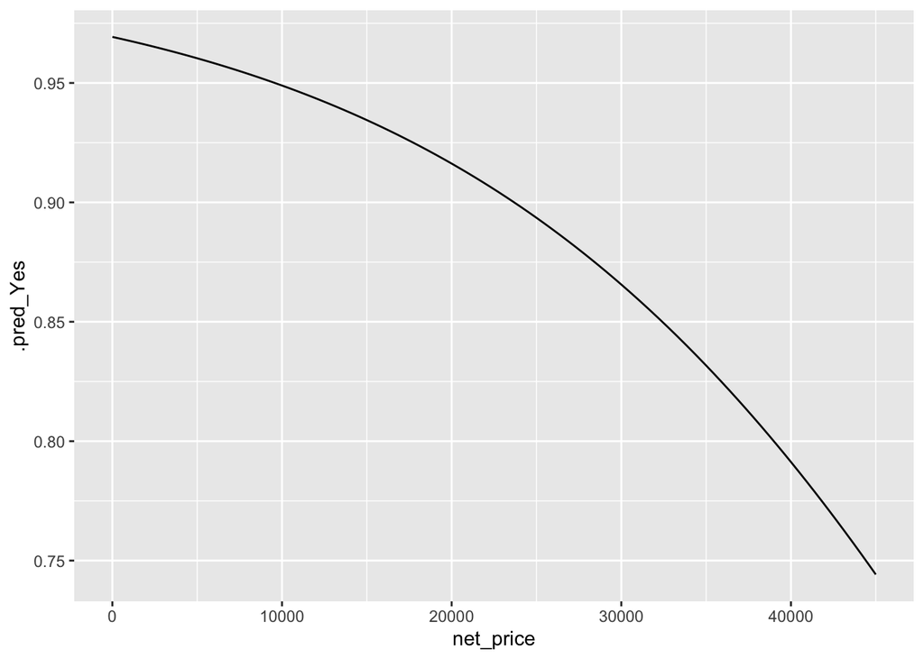

```r
pred_prob%>%
  ggplot(aes(x=net_price,y=.pred_Yes))+
  geom_line()
```